# Term Deposit

Esther

April 20, 2017

# Statement of Business Problem

Hometown Bank has collected its term deposit subscription data from marketing campaigns. The management team would like to know how to improve the number of term deposits and what are the key factors affecting term deposit subscribers.

The bank’s business goal is to predict if a client will subscribe the term deposit through marketing campaign, and requested me to create at least three predictive models that can successfully describe the main characteristic of a successful campaign.

I have done some data analysis, and plan to create ‘Decision Trees’, ‘Random Forest’ and ‘Bagging’ models to help Hometown Bank solving their problems:

# Description of Transaction File

The full dataset has 45K rows with 17 variables each. the bank is interested in understanding the column Y which refers whether the client has subscribed a term deposit. It is a factor with two values: “yes” or “no”.

Field descriptions will be explaining in ‘Terms Definition’ section.

```r
options(scipen = 999)
getwd()
```

```
## [1] "C:/Users/Esther/Documents/1_courses/2_BIA_6301_HW/repo_wrk/script"
```

```r
setwd("C:/Users/Esther/Documents/1_courses/2_BIA_6301_HW/repo_wrk/script")
bank_in <- read.csv("C:/Users/Esther/Documents/1_courses/2_BIA_6301_HW/repo_wrk/data/bank-full.csv")

#str(bank_in)
```

# Terms Definition

- Duration is the last contact duration in second.
- Poutcome is outcome of the previously marketing campaign, it has status of success, failure, unknown and other.
- confusionMatrix table is also called error matrix table, it is a cross-tabulations with two dimensions (“actual” and “predicted”) values.This table is for predictive analysis.
- Month is the last contact month.
- Day is the contact day of the month.
- createDataPartition is a series of test/training data splitting method from ‘Caret’ package.
- Complexity Algorithm (CP) is a method to prune the decision tree and cut off the least important splits.
- Performance function is an algorithm to measure of performance from the prediction object.
- Predictd function: is a function to obtain predictions from a fitted generalized linear model object.
- Pruning a decision tree is a process in reducing the size of the tree, removing unimportant branches.
- rpart is a function for recursive partitioning in decision tree.
- randomForest is an assembling learning method for classification regression.
- sensitivity shows how well the deposit subscribers are correctly predicted.
- specificity shows how well the non-deposit subscribers are correctly predicted.
- Training dataset: 80% of the raw data.
- Testing dataset: 20% of the raw data.

# DATA PREPARATION

‘nrow’ will get the total row count from the table. A formula has created to assign 80% of the raw data to training dataset and 20% of the data to testing dataset.

```r
bank <- bank_in[, c(17,1:16)]                        # move term deposit subscriber (output Y) to the 1st column
maxrow = nrow(bank)                                  # Maximum number of rows from input file
train_set = round( maxrow*(.8) )                     # 80% for training dataset, 20% for test dataset

set.seed(9850)
bank_rand  <- bank[order(runif(maxrow)),]            # generate random ids for each row
bank_train <- bank_rand[1:train_set,]                # 80% for training set
bank_test  <- bank_rand[(train_set+1):maxrow,]       # 20% fro row set

#dim(bank_train)                                      # validate row count
#dim(bank_test)

table(bank_train$y..category)
```

```
##
##    no   yes
## 31979  4190
```

```r
prop.table( table(bank_train$y..category))           # validate fraction data in training set
```

```
##
##        no       yes
## 0.8841549 0.1158451
```

```r
table(bank_test$y..category)
```

```
##
##   no  yes
## 7943 1099
```

```r
prop.table( table(bank_test$y..category))        # validate fraction data in test set
```

```
##
##        no       yes
## 0.8784561 0.1215439
```

# MODEL 1: DECISION TREE

Decision Tree is a classification model, it is using the recursive partitioning algorithm. It chooses the attribute that is most predictive of the target variable. Observations in the training data set are divided into groups of distinct values.

# Data Prepararation

Create a decision tree model from training dataset using method ‘class’ for classification output, ‘gini’ is the splitting index using rpart function. Training data contains 36,169 rows of data

The importance variables are ‘Duration and ’Poutcome’ from the statistical data below.

```r
library(rpart)
library(rpart.plot)

bank_rpart <- rpart(bank_train$y..category~., method="class", parms = list(split="gini"), data=bank_train)
##summary(bank_rpart)
```

# Model 1: Visualization for the Decision Tree

Two variables that predict deposit subscribers are: * Number of seconds in the last contact duration (Duration). * Previously marketing campaign status: success or failure (assuming unknown and others are failure).

```r
options(scipen=999)
# Plot 1
#plot(bank_rpart, uniform=TRUE, main="Decision Tree for Term Deposit Subsrcriber")
#text(bank_rpart, use.n=TRUE, all=TRUE, cex=0.8)

# Plot 2
#library(rpart.plot)
#rpart.plot(bank_rpart, type=1, extra=103, main="Term Deposit Subscribers")
```

# MODEL 1: Evaluate Model Performance. CONFUSION MATRIX - BEFORE PRUNED

Decision Tree Model Performance: * Accuracy rate is 90%. * sensitivity is 33%. * specificity is 98%.

The Accuracy rate of the decision tree model before pruned is 90%, it describes the non-term deposit (specificity is 98%) is predicted better than the term deposit subscribers (sensitivity is 33%).

```r
library(caret)
actual <- bank_test$y..category
predicted <- predict(bank_rpart, bank_test, type="class")
results.matrix <- confusionMatrix(predicted, actual, positive="yes")
print(results.matrix)
```

```
## Confusion Matrix and Statistics
##
##           Reference
## Prediction   no  yes
##        no  7758  739
##        yes  185  360
##
##                Accuracy : 0.8978
##                  95% CI : (0.8914, 0.904)
##     No Information Rate : 0.8785
##     P-Value [Acc > NIR] : 0.000000004468
##
##                   Kappa : 0.3887
##  Mcnemar's Test P-Value : < 0.00000000000000022
##
##             Sensitivity : 0.32757
##             Specificity : 0.97671
##          Pos Pred Value : 0.66055
##          Neg Pred Value : 0.91303
##              Prevalence : 0.12154
##          Detection Rate : 0.03981
##    Detection Prevalence : 0.06027
##       Balanced Accuracy : 0.65214
##
##        'Positive' Class : yes
##
```

# MODEL 1: Using Complexity to prune the Decision Tree

I plan to check if model performance will be improved by applying Complexity Algorithm (CP) to reduce the size of the tree and optimize the decision tree. I selected the minimum CP value from the tree data partitioning.

Run the prune tree (prune) function below. The statistical data below shows no improvement between before and after pruned.

```r
cptable<-printcp(bank_rpart)
```

```
##
## Classification tree:
## rpart(formula = bank_train$y..category ~ ., data = bank_train,
##     method = "class", parms = list(split = "gini"))
##
## Variables actually used in tree construction:
## [1] duration..number   poutcome..category
##
## Root node error: 4190/36169 = 0.11585
##
## n= 36169
##
##         CP nsplit rel error  xerror     xstd
## 1 0.036754      0   1.00000 1.00000 0.014526
## 2 0.027924      3   0.88974 0.90597 0.013911
## 3 0.017422      4   0.86181 0.87303 0.013685
## 4 0.010000      5   0.84439 0.86110 0.013602
```

```r
set.cp.value<-cptable[which.min(cptable[,"xerror"]),"CP"]
Pruned_bank_rpart <- prune(bank_rpart, cp=set.cp.value)

#rpart.plot(Pruned_bank_rpart, type=1, extra=103)
```

# Model 1: Visualize Cross Validation for Pruned Tree

```r
cptable<-printcp(bank_rpart)
```

```
##
## Classification tree:
## rpart(formula = bank_train$y..category ~ ., data = bank_train,
##     method = "class", parms = list(split = "gini"))
##
## Variables actually used in tree construction:
## [1] duration..number   poutcome..category
##
## Root node error: 4190/36169 = 0.11585
##
## n= 36169
##
##         CP nsplit rel error  xerror     xstd
## 1 0.036754      0   1.00000 1.00000 0.014526
## 2 0.027924      3   0.88974 0.90597 0.013911
## 3 0.017422      4   0.86181 0.87303 0.013685
## 4 0.010000      5   0.84439 0.86110 0.013602
```

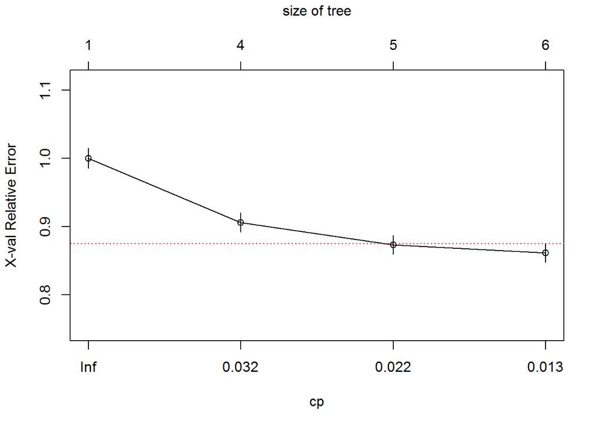

```r
plotcp(bank_rpart, minline=TRUE, col="red")
```

# Model 1: Picking a tree size from Pruned Tree

I look for the “elbow” in the CP plot, pick a tree size at the cp value where the “elbow” occurs, two CP values were selected 0.022 and 0.032.

When CP value = 0.022, plot chart shows the tree has split duration seconds into 3 branches: 521, 827 and 165. When CP value = 0.032, plot chart shows the tree has split duration seconds into 2 branches: 521, 827. The tree has cut off the unimportant branches.

Factors causing deposit subscribers are: * The contact duration (Duration) * The outcome of the previously marketing campaign (Pcoutcome)

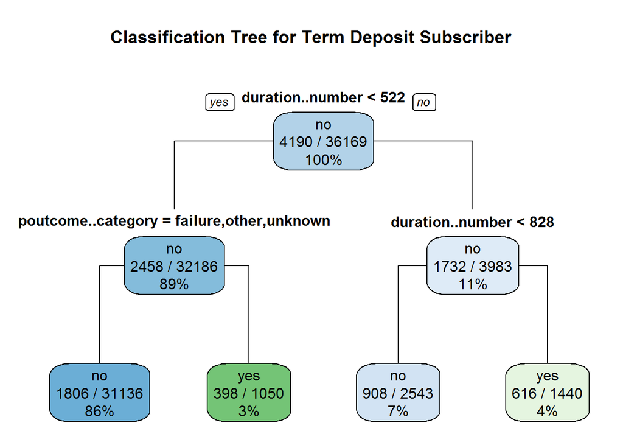

```r
Pruned_bank_rpart <-prune(bank_rpart,cp=.032)

#plot(Pruned_bank_rpart, uniform=TRUE, main="A Tree Size Selected from Pruned Tree")
#text(Pruned_bank_rpart, use.n=TRUE, all=TRUE, cex=.8)

rpart.plot(Pruned_bank_rpart, type=1, extra=103, main="Classification Tree for Term Deposit Subscriber")
```

# MODEL 1b:EVALUATE MODEL PERFORMANCE. CONFUSION MATRIX - AFTER PRUNED with CP Algorithm

After using Complexity Algorithm to improve the tree performance, the performance of the new model does not show any improvment.

Our decision tree model does a better job classifying the non-term deposit than the term deposit subscribers

Comparison of Accuracy rate, sensitivity and specificity are as follows:

AFter pruned with CP: * Accuracy rate is 89%. * sensitivity is 33% * specificity is 97%

Before Pruned: * Accuracy rate is 90%. * sensitivity is 33% * specificity is 98%

```r
actual <- bank_test$y..category
predicted <- predict(Pruned_bank_rpart, bank_test, type="class")
results.matrix <- confusionMatrix(predicted, actual, positive="yes")
print(results.matrix)
```

```
## Confusion Matrix and Statistics
##
##           Reference
## Prediction   no  yes
##        no  7719  734
##        yes  224  365
##
##                Accuracy : 0.894
##                  95% CI : (0.8875, 0.9003)
##     No Information Rate : 0.8785
##     P-Value [Acc > NIR] : 0.000002055
##
##                   Kappa : 0.3799
##  Mcnemar's Test P-Value : < 0.00000000000000022
##
##             Sensitivity : 0.33212
##             Specificity : 0.97180
##          Pos Pred Value : 0.61969
##          Neg Pred Value : 0.91317
##              Prevalence : 0.12154
##          Detection Rate : 0.04037
##    Detection Prevalence : 0.06514
##       Balanced Accuracy : 0.65196
##
##        'Positive' Class : yes
##
```

# MODEL 1b - Using the Caret Package Train and Validate Models

Since the previous decision tree does not show any performance improvement, another approach is to simulate the previous process of estimating the true error, use ‘createDataPartition’ function for data splitting.

Generate random ids create the training set using the following criteria: 80% goes to training, result will not be in the list, one partition to be created 20% goes to test

Validate record count and number of variables from each train and test tables

```r
set.seed(9850)
trainIndex <- createDataPartition(bank$y..category, p = .8,list = FALSE,times = 1)  # 80% goes to training
bank_train_caret <- bank[ trainIndex,]
bank_test_caret <- bank[ -trainIndex,]

dim(bank_train_caret)
```

```
## [1] 36170    17
```

```r
dim(bank_test_caret)
```

```
## [1] 9041   17
```

# Model 1b: Recursive Partitioning using Caret training Dataset

Variable Importance created by recursive data splitting are: duration and poutcome

```r
bank_rpart_caret <- rpart(y..category~., method="class", parms = list(split="gini"), data=bank_train_caret)
#summary(bank_rpart_caret)
```

# Model 1b: Evaluate MODEL PERFORMANCE. Consusion Matrix on caret Package for Performance Improvement

‘caret’ model does not show any performance improvment. model performance comparison are as follows:

Decision Tree Performance Comparison ‘Caret’ Package’: Accuracy rate is 90%, Sensitivity is 31%, Specificity is 97% ‘Pruned with CP’: Accuracy rate is 89%. sensitivity is 33%, specificity is 97% ‘Before Pruned’: Accuracy rate is 90%. sensitivity is 33%, specificity is 98%

```r
# Plot Graph
#plot(bank_rpart_caret, uniform=TRUE, main="Classification Tree for Term Deposit Subscriber")
#text(bank_rpart_caret, use.n=TRUE, all=TRUE, cex=0.8)

#rpart.plot(bank_rpart_caret, type=1, extra=103)

# Confusion Matrix
actual <- bank_test_caret$y..category
predicted <- predict(bank_rpart_caret, bank_test_caret, type="class")
results.matrix <- confusionMatrix(predicted, actual, positive="yes")
print(results.matrix)
```

```
## Confusion Matrix and Statistics
##
##           Reference
## Prediction   no  yes
##        no  7771  730
##        yes  213  327
##
##                Accuracy : 0.8957
##                  95% CI : (0.8892, 0.9019)
##     No Information Rate : 0.8831
##     P-Value [Acc > NIR] : 0.00008121
##
##                   Kappa : 0.3588
##  Mcnemar's Test P-Value : < 0.00000000000000022
##
##             Sensitivity : 0.30937
##             Specificity : 0.97332
##          Pos Pred Value : 0.60556
##          Neg Pred Value : 0.91413
##              Prevalence : 0.11691
##          Detection Rate : 0.03617
##    Detection Prevalence : 0.05973
##       Balanced Accuracy : 0.64134
##
##        'Positive' Class : yes
##
```

# MODEL 2 - Random Forest

My second approach is to use Random Forest algorithm to implement the model. Why Random Forest algorithm?

Random forest algorithm can handle extremely large datasets. it is an ensemble method combine multiple algorithms to obtain better predictive performance. The algorithm is using a subset of the predictors at each split. The node splits are not dominated by strong predictors, it also gives less strong predictors more chances to be used.

```r
library(randomForest)
```

In ‘randomForest’ function, I have set up Term Deposit Subscriber as the output (Y), number of predictors(mstr) is set to 3 for each split, maximum number of trees (mtree) is 500, omit not applicable data, extract important predictors.

The last contact (Duration) is a very significant predictor. This variable is also ranked as top one important variable in decision tree model.

```r
set.seed(9850)
bank_RForest <- randomForest(y..category~.,data=bank_train_caret, mtry=3, ntree=500,na.action = na.omit, importance=TRUE)

#importance(bank_RForest, type = 1)     # important variables measures
#varImpPlot(bank_RForest, type= 1,main=("Variable Importance Rank by Predictors"))
```

# Model 2: Random Forest: Making Predictions

Next step is to evaluate Random Forest Performance using Confusion Matrix and Statistics

Random Forest Model performance: Accuracy : 91% Sensitivity : 47% Specificity : 97%

```r
library(caret)
actual <- bank_test_caret$y..category
bank_predicted <- predict(bank_RForest, newdata=bank_test_caret, type="class")
bank_results_matrix_rf <- confusionMatrix(bank_predicted, actual, positive ="yes")
print(bank_results_matrix_rf)
```

```
## Confusion Matrix and Statistics
##
##           Reference
## Prediction   no  yes
##        no  7729  562
##        yes  255  495
##
##                Accuracy : 0.9096
##                  95% CI : (0.9035, 0.9155)
##     No Information Rate : 0.8831
##     P-Value [Acc > NIR] : 0.0000000000000002317
##
##                   Kappa : 0.4993
##  Mcnemar's Test P-Value : < 0.00000000000000022
##
##             Sensitivity : 0.46831
##             Specificity : 0.96806
##          Pos Pred Value : 0.66000
##          Neg Pred Value : 0.93222
##              Prevalence : 0.11691
##          Detection Rate : 0.05475
##    Detection Prevalence : 0.08296
##       Balanced Accuracy : 0.71818
##
##        'Positive' Class : yes
##
```

# MODEL 2: Random Forest Performance Evaluation Metric using ROC Curve

After evaluating model performance from confusion Matrix, I plan to investigate deposit/non-deposit (sensitivity/Specificity) relationship from ROC curve.

The ROC (receiver operating characteristics) curve displays the true positive rate (sensitivity) against the false positive rate (1-specificity), specificity values are between 0 and 1. The closer the curve follows the left-hand border and then the top left border of the ROC space, the more accurate the model

```r
library(ROCR)
```

# ROC Data Preparation:

Using ‘predict’ function below, I will implement the probability for each term deposit subscriber, each row will include rowid, ‘no’ for non-deposit, yes’ for deposit.

For example: * ID 4: 100% of clients will not subsscribe term deposit. * ID 24: 99.4% of clients will not subsscribe term deposit, 0.6% of client will subsscribe term deposit.

```r
bank_RForest_predict_prob <-predict(bank_RForest, type="prob", newdata=bank_test_caret)
head(bank_RForest_predict_prob)
```

```
##       no   yes
## 4  1.000 0.000
## 11 1.000 0.000
## 12 1.000 0.000
## 17 1.000 0.000
## 23 0.998 0.002
## 24 0.994 0.006
```

# Model 2: Using ROC Curve for cross-validation

Next, I will extract clients who wants to subscribe term deposits (Yes) from predict probability table. Then, I setup parameter values in performance function,“tpr” for true positive rate and “fpr” for false positive rate.

ROC Performance Observation:

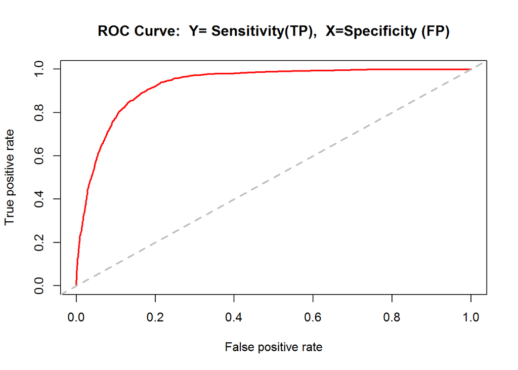

```r
bank_pred = prediction(bank_RForest_predict_prob[,2],bank_test_caret$y..category) #use [,2] to pick the Yes class prob

bank_RForest_perf = performance(bank_pred,"tpr","fpr") #true pos and false pos
plot(bank_RForest_perf ,main="ROC Curve:  Y= Sensitivity(TP),  X=Specificity (FP)",col=2,lwd=2)
abline(a=0,b=1,lwd=2,lty=2,col="gray")
```

```r
#unlist(bank_RForest_perf@y.values) #This is the AUC value (area under the ROC curve)
```

# MODEL 3: BAGGING MODEL

My last approach is to use Bagging algorithm. Bagging is an ensemble algorithm designed to improve the accuracy in prediction.It generates a number of training datasets by bootstrap sampling the original training data.These datasets are then used to generate a set of models using a single learning algorithm.

Bagging averages many trees so it reduces the variance of the instability of generating just one tree. The tradeoff is you lose interpretability and the ability to see simple structure in a tree.

```r
library(randomForest)
```

# Model 3: Data Preparation and Model Performance

In ‘randomForest’algorihm’, I have setup term-deposit as output, number of predictors (mstr) is 16, training dataset, omit not applicable data, allow assess important variables. mstr=16 means all predictors should be considered at each split.

Importance of predictors are generated using parameters above. Top 5 factors have the most impact to term deposit are: Duration, month, day, contact and age.

```r
set.seed(8950)
bank_bag <- randomForest(y..category~., mtry=16, data=bank_train_caret, na.action=na.omit, importance=TRUE)

# drop duration variable, duration is a critical factor to predict term deposit subscribers.
#bank_bag_r <- randomForest(y..category~
#                        bank_train_caret$age..number +
#                        bank_train_caret$job..category+
#                        bank_train_caret$marital..category+
#                        bank_train_caret$education..category+
#                        bank_train_caret$default..category+
#                        bank_train_caret$balance..number+
#                        bank_train_caret$housing..category+
#                        bank_train_caret$loan..category+
#                        bank_train_caret$contact..category+
#                        bank_train_caret$day..number+
#                        bank_train_caret$month..category+
#                        bank_train_caret$campaign..number+
#                        bank_train_caret$pdays..number+
#                        bank_train_caret$previous..number+
#                        bank_train_caret$poutcome..category,
#                        mtry=15, data=bank_train_caret, na.action=na.omit, importance=TRUE)
#print(bank_bag)
#print(bank_bag_r)

importance(bank_bag, type=1)
```

```
##                     MeanDecreaseAccuracy
## age..number                    85.574677
## job..category                  37.000649
## marital..category              18.884322
## education..category            24.950211
## default..category               3.595466
## balance..number                19.804120
## housing..category              73.541761
## loan..category                  6.260447
## contact..category              91.005430
## day..number                   118.516546
## month..category               168.845238
## duration..number              301.766727
## campaign..number               30.617733
## pdays..number                  57.124343
## previous..number               28.876466
## poutcome..category             76.386295
```

```r
#importance(bank_bag_r, type=1)
```

# Model 3: Bagging - Evaluating Model Performance

Bagging model shows 91% accuracy, 5% improvement in predicting term deposit clients(Sensitivity) when comparing to Random Forest. No change in Accuracy, 1% decreased in predicting non-term deposits.

We will look into recommendation section to justify which will be an efficient model to recommend to Hometown management team.

Model 3: Bagging performance: Accuracy : 91%. Sensitivity 52%. Specificity: 96%.

Model 2 (Random Forest) performance: Accuracy : 91%. Sensitivity : 47%. Specificity : 97%.

```r
actual <- bank_test_caret$y..category
bank_predicted <- predict(bank_bag, newdata=bank_test_caret, type="class")
bank_results.matrix.bag <- confusionMatrix(bank_predicted, actual, positive="yes")
print(bank_results.matrix.bag)
```

```
## Confusion Matrix and Statistics
##
##           Reference
## Prediction   no  yes
##        no  7646  509
##        yes  338  548
##
##                Accuracy : 0.9063
##                  95% CI : (0.9001, 0.9122)
##     No Information Rate : 0.8831
##     P-Value [Acc > NIR] : 0.000000000000783
##
##                   Kappa : 0.512
##  Mcnemar's Test P-Value : 0.000000005180464
##
##             Sensitivity : 0.51845
##             Specificity : 0.95767
##          Pos Pred Value : 0.61851
##          Neg Pred Value : 0.93758
##              Prevalence : 0.11691
##          Detection Rate : 0.06061
##    Detection Prevalence : 0.09800
##       Balanced Accuracy : 0.73806
##
##        'Positive' Class : yes
##
```

# Recommendations to Hometown Bank

After evaluating model performance and data analysis, I have summarized the analysis outcomes and recommendation to Hometown Bank management team.

My recommendations are: